# US Recession Probability (12-month Horizon)

## US Risk Premium

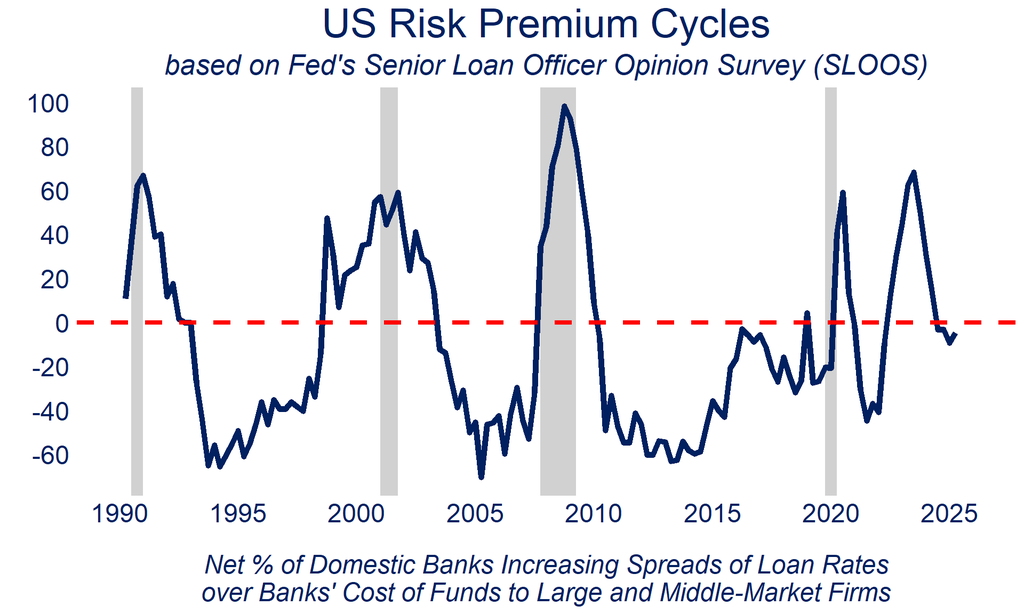

```r
sloos_riskprem<-map_dfr(c("DRISCFLM"),fredr)

recessionsQ.df<-read_csv("NBERchronolQ.csv") %>%
  mutate(Peak=as.Date(Peak,"%d/%m/%Y"),
         Trough=as.Date(Trough,"%d/%m/%Y"))
recessions_riskprem.trim = subset(recessionsQ.df,Peak >= min(sloos_riskprem$date))

ggplot(sloos_riskprem)+
  geom_rect(data=recessions_riskprem.trim,aes(xmin=Peak,xmax=Trough,ymin=-Inf,ymax=+Inf),fill="gray10",alpha=0.2)+
  geom_line(aes(x=date,y=value),color="#002060",linewidth=2)+
  geom_hline(yintercept=0, linetype="dashed",color="red",linewidth=1.5)+
  labs(title="US Risk Premium Cycles",
       subtitle="based on Fed's Senior Loan Officer Opinion Survey (SLOOS)",
       caption="Net % of Domestic Banks Increasing Spreads of Loan Rates\nover Banks' Cost of Funds to Large and Middle-Market Firms",
       x="",y="")+
  scale_y_continuous(breaks=breaks_pretty(10))+
  scale_x_date(breaks=breaks_pretty(10),
               labels=date_format("%Y"),
               limits = as.Date(c("1990-01-01","2026-01-01")))+
  theme(plot.title=element_text(size="28",hjust=0.5,colour="#002060"),
        plot.subtitle=element_text(size="20",hjust=0.5,face="italic",colour="#002060"),
        plot.caption=element_text(size="18",hjust=0.5,face="italic",colour="#002060"),
        axis.text=element_text(color="#002060",size=18),
        legend.text=element_text(color="#002060",size=18),
        legend.position="none",
        legend.background = element_rect(fill='transparent', color=NA), #transparent plot bg
        axis.ticks=element_blank(),
        panel.background = element_rect(fill='transparent'), #transparent panel bg
        plot.background = element_rect(fill='transparent', color=NA), #transparent plot bg
        panel.grid.major=element_blank(),
        panel.grid.minor=element_blank())
```

## US Financial Conditions

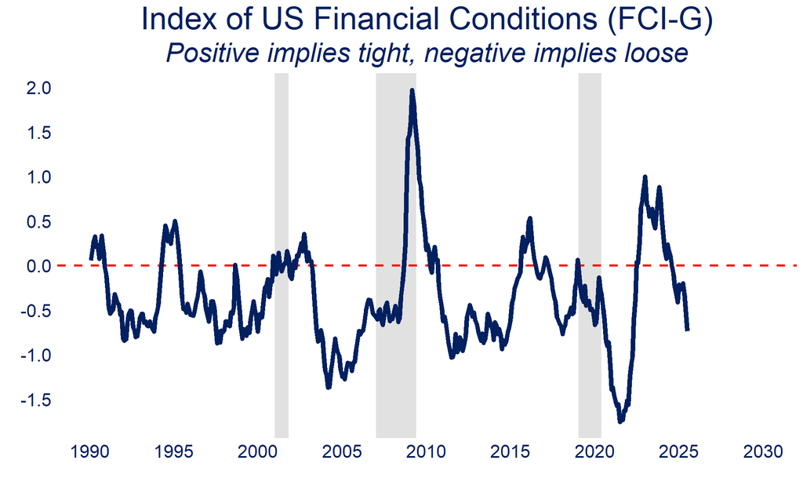

```r
fcig_mth<-read_csv("https://www.federalreserve.gov/econres/notes/feds-notes/fci_g_public_monthly_3yr.csv")

fcig_mth$value<-fcig_mth$`FCI-G Index (baseline)`
fcig_mth<-as.data.frame(fcig_mth) %>%
  mutate(date=as.Date(date)) %>%
  select(date,value)
fcig_mth <- fcig_mth %>%
  mutate(month = as.yearmon(date))

recessions.trim = subset(mrecessions.df,Peak >= min(fcig_mth$date) )
ggplot(fcig_mth)+
  geom_rect(data=recessions.trim,aes(xmin=Peak,xmax=Trough,ymin=-Inf,ymax=+Inf),fill="dimgray",alpha=0.2)+
  geom_hline(yintercept=0, linetype="dashed",color="red",linewidth=1.0)+
  geom_line(aes(x=date,y=value),color="#002060",linewidth=2)+
  labs(title="Index of US Financial Conditions (FCI-G)",
       subtitle="Positive implies tight, negative implies loose",
       x="",y="")+
  scale_y_continuous(breaks=breaks_pretty(10))+
  theme(plot.title=element_text(size="28",hjust=0.5,colour="#002060"),
        plot.subtitle=element_text(size="24",hjust=0.5,face="italic",colour="#002060"),
        axis.title.y.right=element_text(size="18",angle=180,colour="#002060",hjust=1),
        axis.text=element_text(color="#002060",size=16),
        axis.ticks=element_blank(),
        panel.grid.major=element_blank(),
        panel.grid.minor=element_blank(),
        panel.background = element_rect(fill='transparent'),
        plot.background = element_rect(fill='transparent',color=NA))+
  expand_limits(x=as.Date('2030-01-01')) +
  scale_x_date(breaks=breaks_pretty(10))
```

## US Term Premium

```r
url <- "https://www.newyorkfed.org/medialibrary/media/research/data_indicators/ACMTermPremium.xls"
destfile <- tempfile(fileext = ".xls")
download.file(url, destfile, mode = "wb")
term_premium <- read_excel(destfile, sheet = 1)

term_premium_data<-term_premium %>%
  mutate(date = dmy(DATE)) %>%
  dplyr::select(date,
                "UST 10yr Yield"=ACMY10,
                "Risk-Neutral Component"=ACMRNY10,
                "Term Premium Component"=ACMTP10) %>%
  filter(date>="2020-01-01")

term_premium_data_check <- term_premium_data %>%
  mutate(
    calc_yield = `Risk-Neutral Component` + `Term Premium Component`,
    diff = `UST 10yr Yield` - calc_yield
  ) %>%
  filter(date >= as.Date("2020-01-01") & abs(diff) > 1e-6)  # tolerance to avoid rounding issues

# View any inconsistencies
print(term_premium_data_check)
```

```
# A tibble: 0 × 6
# ℹ 6 variables: date <date>, UST 10yr Yield <dbl>,
#   Risk-Neutral Component <dbl>, Term Premium Component <dbl>,
#   calc_yield <dbl>, diff <dbl>
```

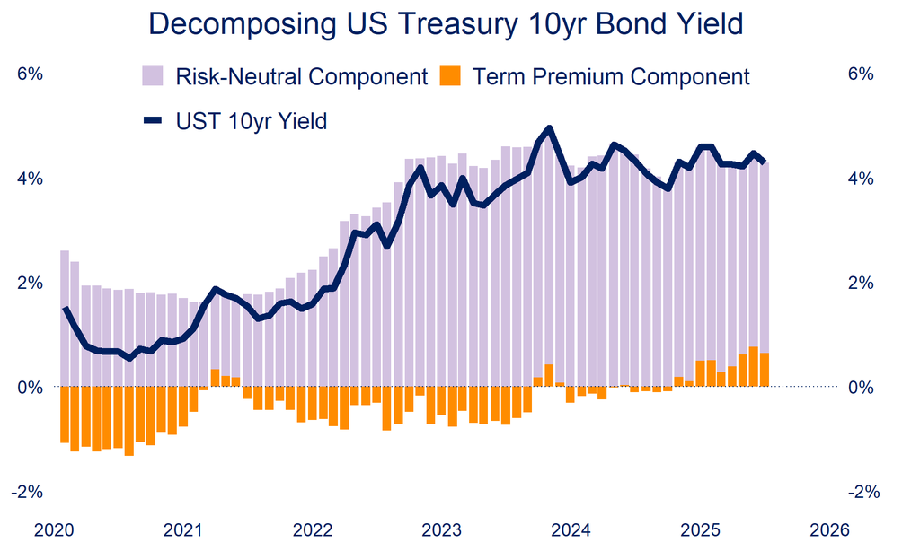

```r
# Reshape to long format for fill mapping
plot_data_long <- term_premium_data %>%
  filter(date >= as.Date("2020-01-01")) %>%
  select(date, `Risk-Neutral Component`, `Term Premium Component`, `UST 10yr Yield`) %>%
  pivot_longer(cols = c(`Risk-Neutral Component`, `Term Premium Component`),
               names_to = "Component", values_to = "Value") %>%
  mutate(Component = factor(Component, levels = c("Risk-Neutral Component", "Term Premium Component")))

term_premium_data <- term_premium_data %>%
  mutate(`Legend Line` = "UST 10yr Yield")

component_fills <- c(
  "Risk-Neutral Component" = "#D2C1E0",
  "Term Premium Component" = "darkorange")

line_color <- c("UST 10yr Yield" = "#002060")

ggplot() +
  geom_col(data = plot_data_long, aes(x = date, y = Value, fill = Component), width = 25) +
  geom_line(data = term_premium_data,
            aes(x = date, y = `UST 10yr Yield`, color = `Legend Line`),
            linewidth = 2.5) +
  geom_hline(yintercept = 0, color = "#002060", linetype = "dotted") +
  scale_fill_manual(values = component_fills) +
  scale_color_manual(values = line_color) +
  guides(
    fill = guide_legend(order = 1),
    color = guide_legend(order = 2)
  ) +
  scale_y_continuous(
    limits = c(-2, 6),
    breaks = seq(-2, 6, by = 2),
    labels = label_percent(scale = 1),
    sec.axis = dup_axis(name = "")
  ) +
  scale_x_date(
    date_breaks = "1 year",
    date_labels = "%Y",
    expand = expansion(mult = c(0, 0.01)),
    limits = c(as.Date("2020-01-01"), as.Date("2026-01-01"))
  ) +
  labs(
    title = "Decomposing US Treasury 10yr Bond Yield",
    x = NULL,
    y = NULL,
    fill = NULL,
    color = NULL
  ) +
  annotate("text", x = as.Date("2020-02-01"), y = 6.1, label = "%", angle = 90,
           color = "#002060", size = 6, hjust = 0) +
  annotate("text", x = as.Date("2026-01-01"), y = 6.1, label = "%", angle = 90,
           color = "#002060", size = 6, hjust = 1) +
  theme_minimal(base_size = 18) +
  theme(
    plot.title=element_text(size="24",hjust=0.5,colour="#002060"),
    panel.grid = element_blank(),
    axis.text = element_text(color = "#002060"),
    axis.ticks=element_blank(),
    legend.key = element_blank(),
    legend.title = element_blank(),
    legend.background = element_blank(),
    legend.text = element_text(color = "#002060", size = 18),
    legend.position = "inside",
    legend.position.inside=c(0.5,0.9),
    legend.box = "vertical",
    legend.spacing.y = unit(0.0, "cm"))+
   guides(fill = guide_legend(order = 1, nrow = 1, byrow = TRUE),
          color = guide_legend(order = 2, nrow = 1, byrow = TRUE))
```

The above chart breaks down the 10-year US Treasury yield into two components: a risk-neutral component and a term premium. The risk-neutral yield reflects the average level of short-term interest rates that the market expects over the next decade. The term premium captures the extra compensation investors demand for holding a long-term bond instead of a series of short-term bonds — a reward for bearing interest rate and inflation risk over time.

Importantly, the term premium can be either positive or negative. When it is positive, the bars stack in the intuitive way: the term premium adds to the risk-neutral yield, and the total (shown by the line) sits above both bars. But when the term premium is negative — which was often the case in previous years — it reduces the overall yield. In such cases, the total yield line sits below the top of the risk-neutral bar, reflecting the fact that investors are willing to accept lower returns in exchange for the safety and liquidity of long-term Treasuries. For the latter part of the Biden era, and certainly during the Trump 2.0 administration, the bond market appears more “yippy” than it has for some time.